# Serie de Fibonacci, Razón Áurea y Filotaxis en R

```r
# Muestra la fecha de la última ejecución del proyecto
print(paste0("Última ejecución: ", date()))
```

```
[1] "Última ejecución: Fri Jan  3 17:18:26 2020"
```

# Contenido

1. Introducción
2. Parte 1 Funciones
3. Números de Fibonacci
4. Serie con *m* elementos
5. Razón Áurea
6. Parte 2 Filotaxis
7. Coméntanos

# Introducción

En este proyecto realizaremos una serie de ejercicios que nos permitirán generar la serie de Fibonacci y encontrar la razón áurea definiendo funciones recursivas en lenguaje R. Además generaremos interesantes visualizaciones obedeciendo el ángulo de Fibonacci que simulan la filotaxis en la naturaleza.  
Con el desarrollo de este proyecto podremos practicar el uso de variables, dataframes, funciones y visualizaciones con ggplot2.

[figure not shown]

Regresar al inicio

# Parte 1. Funciones

En esta parte definiremos funciones en lenguaje R para generar elementos de la serie de Fibonacci, la serie con m elementos, y obtener la razón áurea.

## 1.1 Función Recursiva para Generar Números de Fibonacci

```r
# Importamos las librerías que usaremos en el proyecto

# Con este comando desactivamos la impresión de warnings (versiones de CRAN y ggplot2)
options(warn = -1)
library(ggplot2)
```

La función *fib* genera el n-ésimo número de la serie:

```r
fib <- function(n) {

  if (n == 1) {

      return(0)
  }
  else if(n == 2) {

      return(1)
  }
  else if(n > 2) {

      return(fib(n - 1) + fib(n - 2))
  }

}
```

Apliquemos la función *fib* para generar el octavo número de la serie:

```r
print(fib(8))
```

```
[1] 13
```

## 1.2 Función para Generar la Serie con *m* elementos

Dentro de la función declaramos un vector *serie* en el que acularemos los elementos que se generan con ciclo *for* que repite la aplicación de la función *fib*.

```r
s_fib <- function(m) {

    serie <- vector("numeric", length = m)

    for (i in 1:m) {

        serie[i] <- fib(i)
    }

    return(serie)
}
```

Apliquemos la función *s_fib* para generar 20 elementos de la serie:

```r
print(s_fib(20))
```

```
 [1]    0    1    1    2    3    5    8   13   21   34   55   89  144  233  377
[16]  610  987 1597 2584 4181
```

## 1.3 Función para Obtener la Razón Áurea

Obtendremos la razón áurea definiendo una función *r_oro* que dividirá el n-ésimo número de la serie entre su predecesor.

```r
r_oro <- function(n) {

  if (n <= 4) {

      return('Utiliza un número mayor a 4')
  }

    else (return(fib(n)/fib(n-1)))

}
```

```r
print(r_oro(30))
```

```
[1] 1.618034
```

## Razón Áurea

$$ \phi = \frac{1+\sqrt{5}}{2} \sim{1.618033989} $$

## Ángulo de Fibonacci

$$ \alpha = 360°* \Bigg(\frac{2}{1 + \sqrt{5}}\Bigg)^{2} \sim{137.5°} $$

Regresar al inicio

# Parte 2. Filotaxis

Utilizando el ángulo de Fibonacci crearemos un dataframe con tres coordenas correspondientes al factor alpha (ángulo), la órdenada y la abcisa las cuales graficaremos en dos dimensiones y haremos algunas variaciones para simular la filotaxia en la naturaleza.

## 2.1 Girasol

```r
# Ajustamos el tamaño de las gráficas
options(repr.plot.width=5, repr.plot.height=5)
```

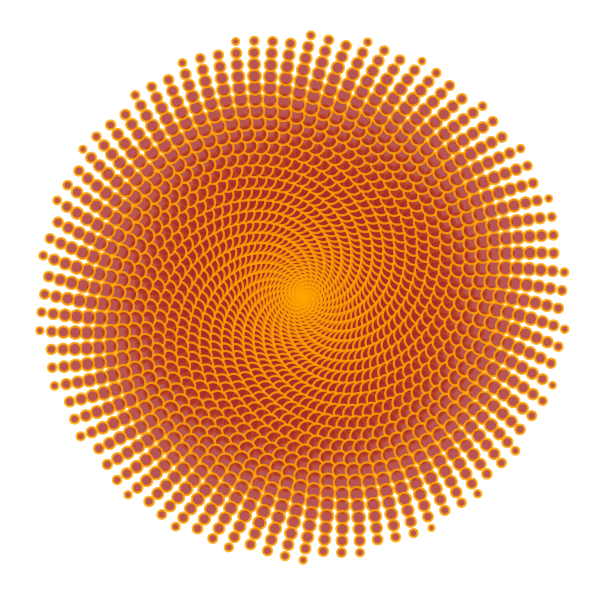

```r
# Número de puntos en la visualización
n <- 2000

# Ángulo de Fibonacci
alpha <- 360*((2 / (sqrt(5) + 1))**2)

# Elementos que formarán las espirales
s <- -(1:n)*alpha
x <- sin(s)
y <- cos(s)

# Creamos un dataframe con los valores
df <- data.frame(s, x, y)

# Creamos la gráfica
p <- ggplot(df, aes(x*s, y*s))

# Estéticos
p + geom_point(aes(size = s),
               alpha = 0.8,
               color = "orange",
               fill = 'brown',
               shape = 21,
               stroke = 1) +

theme(panel.background = element_rect(fill = "white"),
      panel.grid = element_blank(),
      axis.text = element_blank(),
      axis.title = element_blank(),
      axis.line = element_blank(),
      axis.ticks = element_blank(),
      legend.position = "none")
```

## 2.2. Floración Amarilla de Girasol

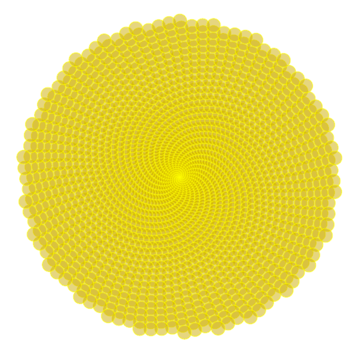

```r
n <- 2000
alpha <- 360*((2 / (sqrt(5) + 1))**2)


s <- (1:n)*alpha
x <- sin(s)
y <- cos(s)

df <- data.frame(s, x, y)

p <- ggplot(df, aes(x*s, y*s))

p + geom_point(aes(size = s),
               alpha = 0.5,
               color = "yellow",
               fill = 'gold3',
               shape = 21,
               stroke = 0.8) +

theme(panel.background = element_rect(fill = "white"),
      panel.grid = element_blank(),
      axis.text = element_blank(),
      axis.title = element_blank(),
      axis.line = element_blank(),
      axis.ticks = element_blank(),
      legend.position = "none")
```

## 1.3. Cáctus

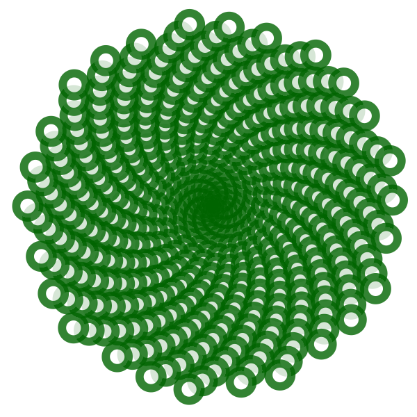

```r
n <- 500
alpha <- 360*((2 / (sqrt(5) + 1))**2)


s <- (1:n)*alpha
x <- sin(s)
y <- cos(s)

df <- data.frame(s, x, y)

p <- ggplot(df, aes(x*s, y*s))

p + geom_point(aes(size = s),
               alpha = 0.8,
               color = "darkgreen",
               fill = 'white',
               shape = 21,
               stroke = 5) +

theme(panel.background = element_rect(fill = "white"),
      panel.grid = element_blank(),
      axis.text = element_blank(),
      axis.title = element_blank(),
      axis.line = element_blank(),
      axis.ticks = element_blank(),
      legend.position = "none")
```

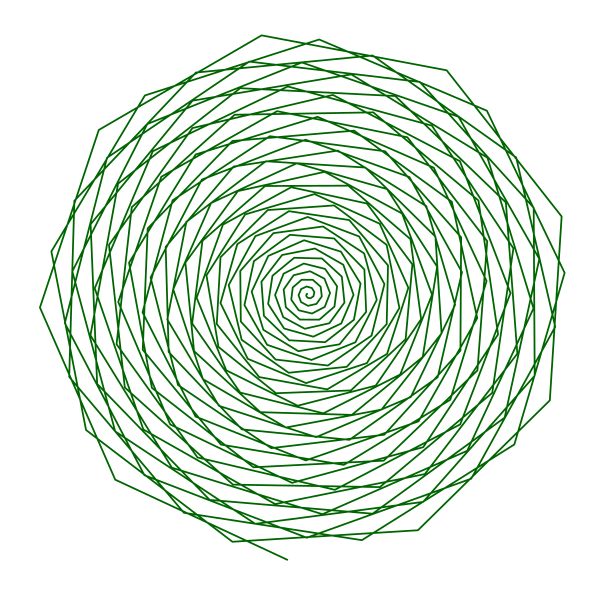

```r
n <- 300
alpha <- 360*((2 / (sqrt(5) + 1))**2)


s <- (1:n)*alpha
x <- sin(s)
y <- cos(s)

df <- data.frame(s, x, y)

p <- ggplot(df, aes(x*s, y*s))

p + geom_path(color = "darkgreen") +

theme(panel.background = element_rect(fill = "white"),
      panel.grid = element_blank(),
      axis.text = element_blank(),
      axis.title = element_blank(),
      axis.line = element_blank(),
      axis.ticks = element_blank(),
      legend.position = "none")
```

Regresar al inicio

## Síguenos en Facebook

[figure not shown]

## Esperamos con gusto tus comentarios y sugerencias para incrementar y mejorar este proyecto: